# RST Data Annual QC

Published

June 17, 2026

```r
library(tidyverse)
library(lubridate)
library(here)
library(glue)
library(DT)

# Load package data (works from source or installed)
if (file.exists(here::here("DESCRIPTION"))) {
  devtools::load_all(here::here(), quiet = TRUE)
} else {
  library(SRJPEdata)
}

source(here::here("data-raw", "qc", "qc_helpers.R"))

review_run_year <- params$review_run_year
```

## Overview

Reviewing RST catch and trap data. Run year being reviewed: **2026**.

Data sources: `rst_catch`, `rst_trap`, `weekly_juvenile_abundance_catch_data`, `years_to_exclude_rst_data`.

RST catch records by stream and site

| stream | site | min_run_year | max_run_year | total_records |
| --- | --- | --- | --- | --- |
| battle creek | lbc | 1998 | 2016 | 31666 |
| battle creek | ubc | 1998 | 2026 | 46966 |
| butte creek | adams dam | 1997 | 1998 | 761 |
| butte creek | okie dam | 1996 | 2026 | 94365 |
| clear creek | lcc | 1999 | 2026 | 312567 |
| clear creek | ucc | 2003 | 2026 | 65333 |
| deer creek | deer creek | 1992 | 2026 | 26521 |
| feather river | eye riffle | 1998 | 2026 | 68810 |
| feather river | gateway riffle | 2013 | 2017 | 19030 |
| feather river | herringer riffle | 2002 | 2026 | 118312 |
| feather river | live oak | 1998 | 2002 | 8099 |
| feather river | steep riffle | 2006 | 2016 | 24700 |
| feather river | sunset pumps | 2007 | 2025 | 16658 |
| mill creek | mill creek | 1996 | 2026 | 27513 |
| sacramento river | knights landing | 1996 | 2026 | 177068 |
| sacramento river | tisdale | 2010 | 2024 | 57679 |
| yuba river | hallwood | 2000 | 2026 | 146035 |

## Check 1: Fork Length — High NA Rate

Flag stream/site/run_years where >95% of records have no fork length recorded and total records exceed 50. Indicates a season where measurements were not taken.

```r
fl_na_check <- rst_catch |>
  filter(!is.na(date)) |>
  mutate(run_year = as_run_year(date)) |>
  group_by(stream, site, run_year) |>
  summarise(
    n_records    = n(),
    n_na_fl      = sum(is.na(fork_length)),
    pct_na_fl    = round(mean(is.na(fork_length)) * 100, 1),
    .groups      = "drop"
  ) |>
  filter(pct_na_fl > 95, n_records > 50)

new_fl_na <- log_issues(
  fl_na_check |>
    mutate(
      data_type   = "rst",
      issue_type  = "high_na_rate",
      field       = "fork_length",
      severity    = "moderate",
      description = glue("{n_na_fl} of {n_records} records ({pct_na_fl}%) have no fork length in run year {run_year} at {site} ({stream})")
    )
)
```

```
  + 4 new issue(s) logged. 0 already in log.
```

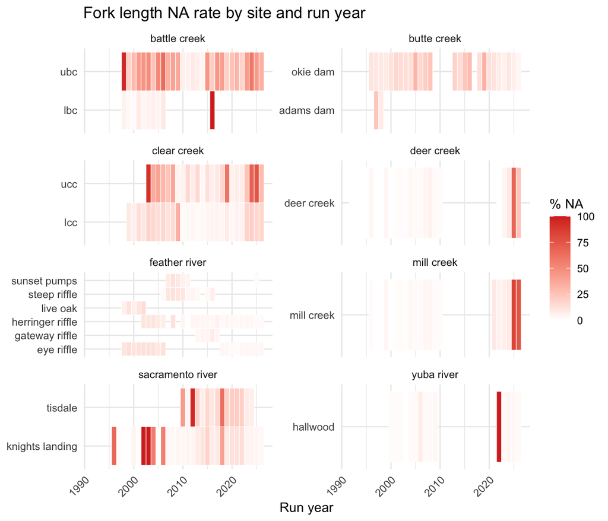

4 site/run-year combination(s) flagged.

## Check 2: Fork Length — Implausible Values

Flag records where `fork_length < 20mm` or `fork_length > 200mm`. These are biologically implausible for juvenile chinook at an RST.

```r
fl_impl_check <- rst_catch |>
  filter(!is.na(fork_length), fork_length > 0) |>
  mutate(run_year = as_run_year(date)) |>
  mutate(implausible = fork_length < 20 | fork_length > 200) |>
  group_by(stream, site, run_year) |>
  summarise(
    n_records    = sum(implausible),
    min_fl       = min(fork_length[implausible], na.rm = TRUE),
    max_fl       = max(fork_length[implausible], na.rm = TRUE),
    .groups      = "drop"
  ) |>
  filter(n_records > 0)
new_fl_impl <- log_issues(
  fl_impl_check |>
    mutate(
      data_type   = "rst",
      issue_type  = "implausible_value",
      field       = "fork_length",
      severity    = "critical",
      description = glue("{n_records} record(s) with fork_length <20mm or >200mm in run year {run_year} at {site} ({stream}). Range of flagged values: [{min_fl}, {max_fl}]mm")
    )
)
```

```
  + 64 new issue(s) logged. 0 already in log.
```

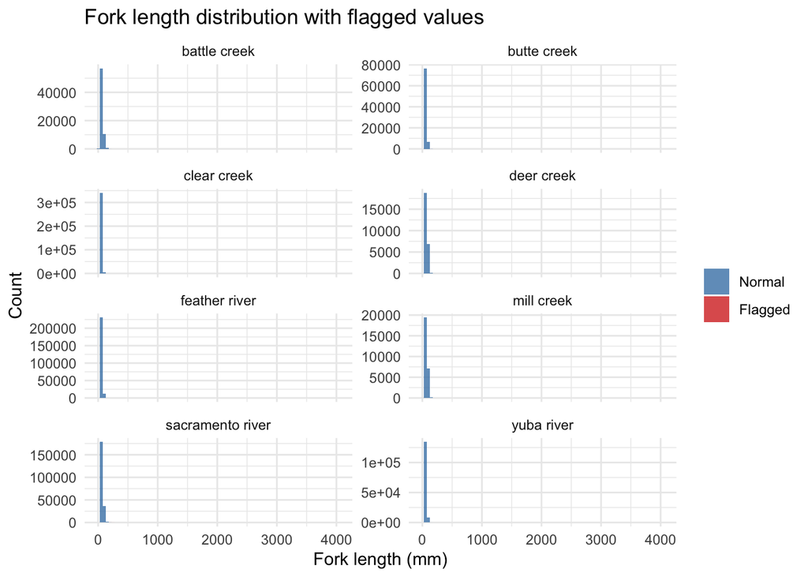

64 site/run-year combination(s) flagged.

## Check 3: Catch — Extreme Annual Totals

Flag run_years where total catch at a site exceeds 4× the site’s historical median. Requires at least 5 years of history. Not necessarily an error — warrants review.

```r
annual_catch <- rst_catch |>
  filter(!is.na(date), !is.na(count)) |>
  mutate(run_year = as_run_year(date)) |>
  group_by(stream, site, run_year) |>
  summarise(total_catch = sum(count, na.rm = TRUE), .groups = "drop")

site_stats <- annual_catch |>
  group_by(stream, site) |>
  summarise(
    n_years      = n(),
    median_catch = median(total_catch),
    .groups      = "drop"
  ) |>
  filter(n_years >= 5, median_catch > 0)

catch_extreme <- annual_catch |>
  inner_join(site_stats, by = c("stream", "site")) |>
  filter(total_catch > 4 * median_catch)

new_catch_extreme <- log_issues(
  catch_extreme |>
    mutate(
      n_records   = 1L,
      data_type   = "rst",
      issue_type  = "extreme_value",
      field       = "count",
      severity    = "minor",
      description = glue("Total catch of {total_catch} in run year {run_year} at {site} ({stream}) is {round(total_catch / median_catch, 1)}x the site median ({median_catch})")
    )
)
```

```
  + 47 new issue(s) logged. 0 already in log.
```

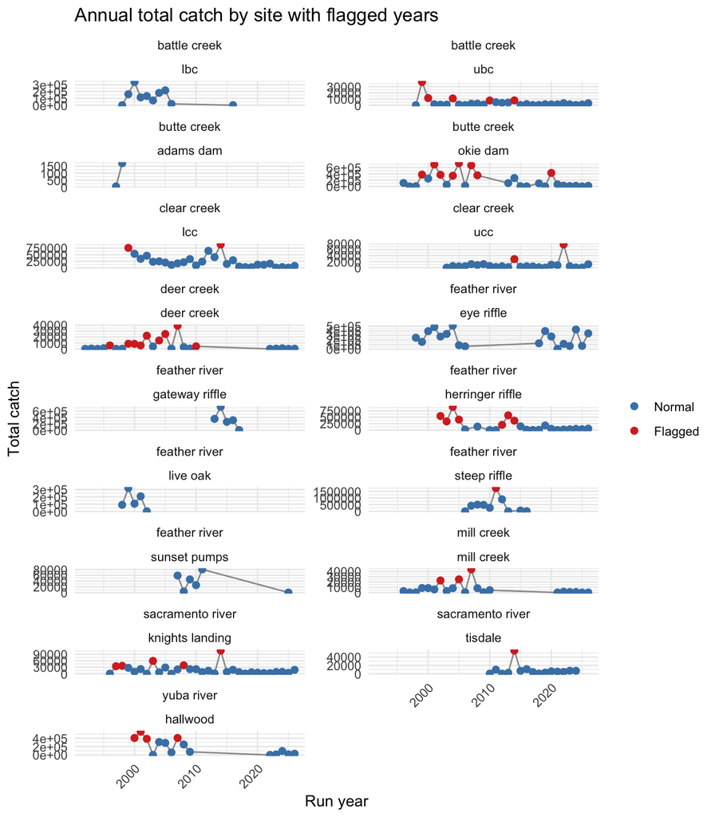

47 site/run-year combination(s) flagged.

## Check 4: Season Coverage — Low Sampling Effort

Flag all stream/site/run_years with fewer than 3 weeks sampled in the BTSPAS window (weeks 45–53 and 1–22), including those already in `years_to_exclude_rst_data`. The description notes exclusion status.

```r
weeks_in_window <- weekly_juvenile_abundance_catch_data |>
  filter(week %in% c(45:53, 1:22), !is.na(count)) |>
  group_by(stream, site, run_year) |>
  summarise(weeks_sampled = n_distinct(week), .groups = "drop")

excluded_lookup <- years_to_exclude_rst_data |>
  distinct(stream, site, run_year) |>
  mutate(already_excluded = TRUE)

low_effort <- weeks_in_window |>
  filter(weeks_sampled < 3) |>
  left_join(excluded_lookup, by = c("stream", "site", "run_year")) |>
  mutate(already_excluded = replace_na(already_excluded, FALSE))

new_low_effort <- log_issues(
  low_effort |>
    mutate(
      n_records   = weeks_sampled,
      data_type   = "rst",
      issue_type  = "low_sampling_effort",
      field       = "weeks_sampled",
      severity    = "moderate",
      description = glue("Only {weeks_sampled} week(s) sampled in BTSPAS window for run year {run_year} at {site} ({stream}). Already excluded from modeling: {already_excluded}")
    )
)
```

```
  + 5 new issue(s) logged. 0 already in log.
```

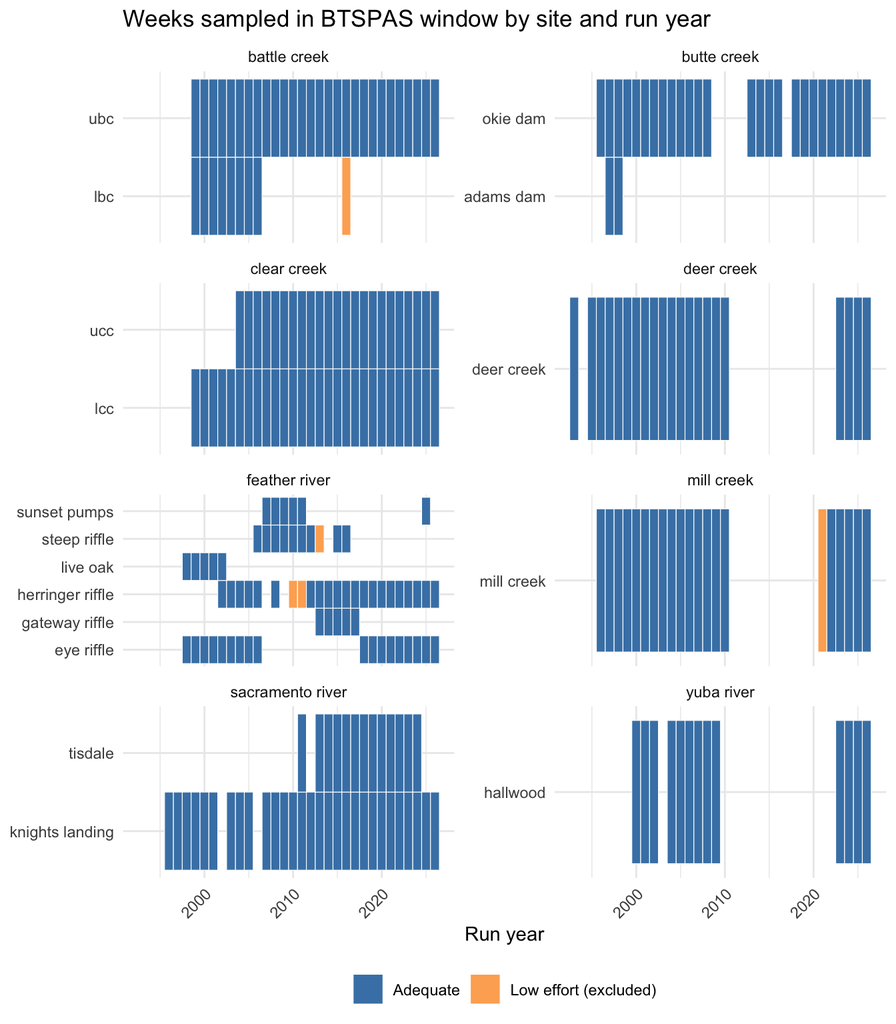

5 site/run-year combination(s) flagged (5 already excluded from modeling).

## Issues Logged This Run

| log_id | stream | site | run_year | issue_type | field | severity | description |
| --- | --- | --- | --- | --- | --- | --- | --- |
| rst__battle_creek__ubc__1998__high_na_rate__fork_length | battle creek | ubc | 1998 | high_na_rate | fork_length | moderate | 58 of 61 records (95.1%) have no fork length in run year 1998 at ubc (battle creek) |
| rst__sacramento_river__knights_landing__2002__high_na_rate__fork_length | sacramento river | knights landing | 2002 | high_na_rate | fork_length | moderate | 56 of 56 records (100%) have no fork length in run year 2002 at knights landing (sacramento river) |
| rst__sacramento_river__knights_landing__2003__high_na_rate__fork_length | sacramento river | knights landing | 2003 | high_na_rate | fork_length | moderate | 1444 of 1444 records (100%) have no fork length in run year 2003 at knights landing (sacramento river) |
| rst__sacramento_river__tisdale__2012__high_na_rate__fork_length | sacramento river | tisdale | 2012 | high_na_rate | fork_length | moderate | 114 of 119 records (95.8%) have no fork length in run year 2012 at tisdale (sacramento river) |
| rst__battle_creek__lbc__2000__implausible_value__fork_length | battle creek | lbc | 2000 | implausible_value | fork_length | critical | 2 record(s) with fork_length &lt;20mm or &gt;200mm in run year 2000 at lbc (battle creek). Range of flagged values: [205, 232]mm |
| rst__battle_creek__lbc__2002__implausible_value__fork_length | battle creek | lbc | 2002 | implausible_value | fork_length | critical | 1 record(s) with fork_length &lt;20mm or &gt;200mm in run year 2002 at lbc (battle creek). Range of flagged values: [19, 19]mm |
| rst__battle_creek__lbc__2005__implausible_value__fork_length | battle creek | lbc | 2005 | implausible_value | fork_length | critical | 3 record(s) with fork_length &lt;20mm or &gt;200mm in run year 2005 at lbc (battle creek). Range of flagged values: [19, 220]mm |
| rst__battle_creek__ubc__2006__implausible_value__fork_length | battle creek | ubc | 2006 | implausible_value | fork_length | critical | 5 record(s) with fork_length &lt;20mm or &gt;200mm in run year 2006 at ubc (battle creek). Range of flagged values: [6, 6]mm |
| rst__battle_creek__ubc__2023__implausible_value__fork_length | battle creek | ubc | 2023 | implausible_value | fork_length | critical | 1 record(s) with fork_length &lt;20mm or &gt;200mm in run year 2023 at ubc (battle creek). Range of flagged values: [209, 209]mm |
| rst__butte_creek__okie_dam__1999__implausible_value__fork_length | butte creek | okie dam | 1999 | implausible_value | fork_length | critical | 2 record(s) with fork_length &lt;20mm or &gt;200mm in run year 1999 at okie dam (butte creek). Range of flagged values: [630, 800]mm |

[output cut: 110 more lines]

### All Open RST Issues

| log_id | date_identified | stream | site | run_year | issue_type | field | severity | description | reviewer_notes |
| --- | --- | --- | --- | --- | --- | --- | --- | --- | --- |
| rst__battle_creek__ubc__1998__high_na_rate__fork_length | 2026-06-17 | battle creek | ubc | 1998 | high_na_rate | fork_length | moderate | 58 of 61 records (95.1%) have no fork length in run year 1998 at ubc (battle creek) |  |
| rst__sacramento_river__knights_landing__2002__high_na_rate__fork_length | 2026-06-17 | sacramento river | knights landing | 2002 | high_na_rate | fork_length | moderate | 56 of 56 records (100%) have no fork length in run year 2002 at knights landing (sacramento river) |  |
| rst__sacramento_river__knights_landing__2003__high_na_rate__fork_length | 2026-06-17 | sacramento river | knights landing | 2003 | high_na_rate | fork_length | moderate | 1444 of 1444 records (100%) have no fork length in run year 2003 at knights landing (sacramento river) |  |
| rst__sacramento_river__tisdale__2012__high_na_rate__fork_length | 2026-06-17 | sacramento river | tisdale | 2012 | high_na_rate | fork_length | moderate | 114 of 119 records (95.8%) have no fork length in run year 2012 at tisdale (sacramento river) |  |
| rst__battle_creek__lbc__2000__implausible_value__fork_length | 2026-06-17 | battle creek | lbc | 2000 | implausible_value | fork_length | critical | 2 record(s) with fork_length &lt;20mm or &gt;200mm in run year 2000 at lbc (battle creek). Range of flagged values: [205, 232]mm |  |
| rst__battle_creek__lbc__2002__implausible_value__fork_length | 2026-06-17 | battle creek | lbc | 2002 | implausible_value | fork_length | critical | 1 record(s) with fork_length &lt;20mm or &gt;200mm in run year 2002 at lbc (battle creek). Range of flagged values: [19, 19]mm |  |
| rst__battle_creek__lbc__2005__implausible_value__fork_length | 2026-06-17 | battle creek | lbc | 2005 | implausible_value | fork_length | critical | 3 record(s) with fork_length &lt;20mm or &gt;200mm in run year 2005 at lbc (battle creek). Range of flagged values: [19, 220]mm |  |
| rst__battle_creek__ubc__2006__implausible_value__fork_length | 2026-06-17 | battle creek | ubc | 2006 | implausible_value | fork_length | critical | 5 record(s) with fork_length &lt;20mm or &gt;200mm in run year 2006 at ubc (battle creek). Range of flagged values: [6, 6]mm |  |
| rst__battle_creek__ubc__2023__implausible_value__fork_length | 2026-06-17 | battle creek | ubc | 2023 | implausible_value | fork_length | critical | 1 record(s) with fork_length &lt;20mm or &gt;200mm in run year 2023 at ubc (battle creek). Range of flagged values: [209, 209]mm |  |
| rst__butte_creek__okie_dam__1999__implausible_value__fork_length | 2026-06-17 | butte creek | okie dam | 1999 | implausible_value | fork_length | critical | 2 record(s) with fork_length &lt;20mm or &gt;200mm in run year 1999 at okie dam (butte creek). Range of flagged values: [630, 800]mm |  |

[output cut: 110 more lines]